# Risk Factor Analysis

## Outcome Variable

**Outcome Variable:** stunted

## Predictor Variables

**Intervention Variable:** gagebrth

**Adjustment Set:**

unadjusted

## Stratifying Variables

The analysis was stratified on these variable(s):

- agecat
- studyid
- country

## Data Summary

| agecat | studyid | country | gagebrth | stunted | n_cell | n |
| --- | --- | --- | --- | --- | --- | --- |
| Birth | CMC-V-BCS-2002 | INDIA | Full or late term | 0 | 48 | 92 |
| Birth | CMC-V-BCS-2002 | INDIA | Full or late term | 1 | 10 | 92 |
| Birth | CMC-V-BCS-2002 | INDIA | Preterm | 0 | 8 | 92 |
| Birth | CMC-V-BCS-2002 | INDIA | Preterm | 1 | 3 | 92 |
| Birth | CMC-V-BCS-2002 | INDIA | Early term | 0 | 19 | 92 |
| Birth | CMC-V-BCS-2002 | INDIA | Early term | 1 | 4 | 92 |
| Birth | COHORTS | GUATEMALA | Full or late term | 0 | 330 | 617 |
| Birth | COHORTS | GUATEMALA | Full or late term | 1 | 11 | 617 |
| Birth | COHORTS | GUATEMALA | Preterm | 0 | 82 | 617 |
| Birth | COHORTS | GUATEMALA | Preterm | 1 | 13 | 617 |
| Birth | COHORTS | GUATEMALA | Early term | 0 | 170 | 617 |
| Birth | COHORTS | GUATEMALA | Early term | 1 | 11 | 617 |
| Birth | COHORTS | INDIA | Full or late term | 0 | 536 | 1293 |
| Birth | COHORTS | INDIA | Full or late term | 1 | 34 | 1293 |
| Birth | COHORTS | INDIA | Preterm | 0 | 242 | 1293 |
| Birth | COHORTS | INDIA | Preterm | 1 | 43 | 1293 |
| Birth | COHORTS | INDIA | Early term | 0 | 391 | 1293 |
| Birth | COHORTS | INDIA | Early term | 1 | 47 | 1293 |
| Birth | COHORTS | PHILIPPINES | Full or late term | 0 | 1128 | 3024 |
| Birth | COHORTS | PHILIPPINES | Full or late term | 1 | 36 | 3024 |
| Birth | COHORTS | PHILIPPINES | Preterm | 0 | 561 | 3024 |
| Birth | COHORTS | PHILIPPINES | Preterm | 1 | 88 | 3024 |
| Birth | COHORTS | PHILIPPINES | Early term | 0 | 1150 | 3024 |
| Birth | COHORTS | PHILIPPINES | Early term | 1 | 61 | 3024 |
| Birth | IRC | INDIA | Full or late term | 0 | 211 | 369 |
| Birth | IRC | INDIA | Full or late term | 1 | 27 | 369 |
| Birth | IRC | INDIA | Preterm | 0 | 27 | 369 |
| Birth | IRC | INDIA | Preterm | 1 | 9 | 369 |
| Birth | IRC | INDIA | Early term | 0 | 87 | 369 |
| Birth | IRC | INDIA | Early term | 1 | 8 | 369 |

[output cut: 126 more lines]

The following strata were considered:

- agecat: 24 months, studyid: CMC-V-BCS-2002, country: INDIA
- agecat: 24 months, studyid: COHORTS, country: GUATEMALA
- agecat: 24 months, studyid: COHORTS, country: INDIA
- agecat: 24 months, studyid: COHORTS, country: PHILIPPINES
- agecat: 24 months, studyid: IRC, country: INDIA
- agecat: 24 months, studyid: Keneba, country: GAMBIA
- agecat: 24 months, studyid: NIH-Crypto, country: BANGLADESH
- agecat: 24 months, studyid: PROBIT, country: BELARUS
- agecat: 24 months, studyid: TanzaniaChild2, country: TANZANIA, UNITED REPUBLIC OF
- agecat: 6 months, studyid: CMC-V-BCS-2002, country: INDIA
- agecat: 6 months, studyid: COHORTS, country: GUATEMALA
- agecat: 6 months, studyid: COHORTS, country: INDIA
- agecat: 6 months, studyid: COHORTS, country: PHILIPPINES
- agecat: 6 months, studyid: IRC, country: INDIA
- agecat: 6 months, studyid: Keneba, country: GAMBIA
- agecat: 6 months, studyid: NIH-Crypto, country: BANGLADESH
- agecat: 6 months, studyid: PROBIT, country: BELARUS
- agecat: 6 months, studyid: TanzaniaChild2, country: TANZANIA, UNITED REPUBLIC OF
- agecat: Birth, studyid: CMC-V-BCS-2002, country: INDIA
- agecat: Birth, studyid: COHORTS, country: GUATEMALA
- agecat: Birth, studyid: COHORTS, country: INDIA
- agecat: Birth, studyid: COHORTS, country: PHILIPPINES
- agecat: Birth, studyid: IRC, country: INDIA
- agecat: Birth, studyid: Keneba, country: GAMBIA
- agecat: Birth, studyid: NIH-Crypto, country: BANGLADESH
- agecat: Birth, studyid: PROBIT, country: BELARUS

### Dropped Strata

Some strata were dropped due to rare outcomes:

- agecat: Birth, studyid: CMC-V-BCS-2002, country: INDIA
- agecat: 24 months, studyid: TanzaniaChild2, country: TANZANIA, UNITED REPUBLIC OF

## Methods Detail

We’re interested in the causal parameters $E[Y_a]$ for all values of $a \in \mathcal{A}$. These parameters represent the mean outcome if, possibly contrary to fact, we intervened to set all units to have $A=a$. Under the randomization and positivity assumptions, these are identified by the statistical parameters $\psi_a=E_W[E_{Y|A,W}(Y|A=a,W)]$. In addition, we’re interested in the mean of $Y$, $E[Y]$ under no intervention (the observed mean). We will estimate these parameters by using SuperLearner to fit the relevant likelihood factors – $E_{Y|A,W}(Y|A=a,W)$ and $p(A=a|W)$, and then updating our likelihood fit using a joint TMLE.

For unadjusted analyses ($W=\{\}$), initial likelihoods were estimated using Lrnr_glm to estimate the simple $E(Y|A)$ and Lrnr_mean to estimate $p(A)$. For adjusted analyses, a small library containing Lrnr_glmnet, Lrnr_xgboost, and Lrnr_mean was used.

Having estimated these parameters, we will then use the delta method to estimate relative risks and attributable risks relative to a prespecified baseline level of $A$.

# Results Detail

## Results Plots

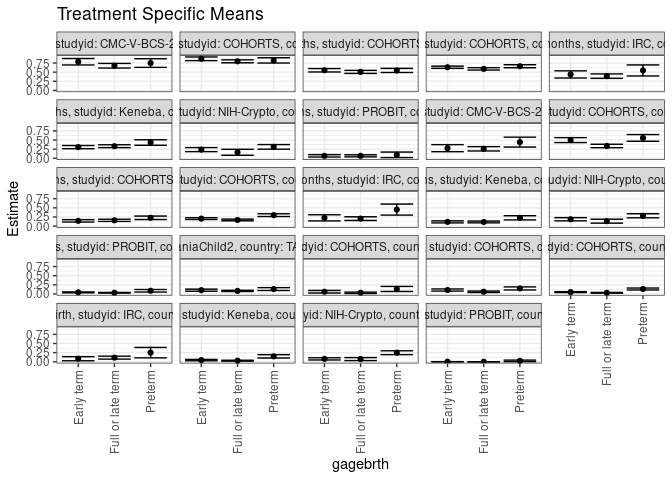

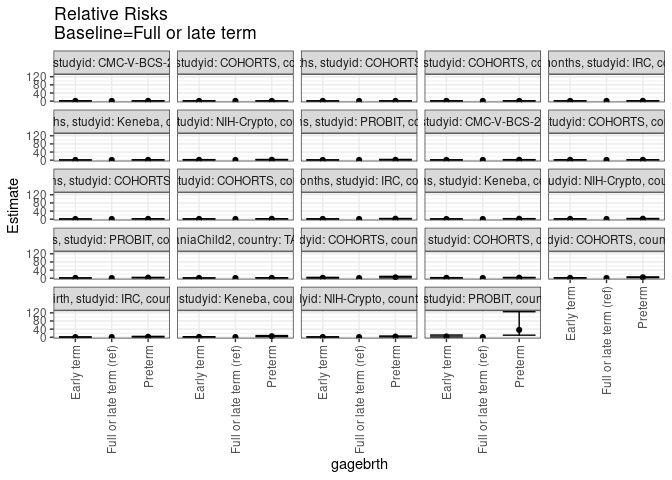

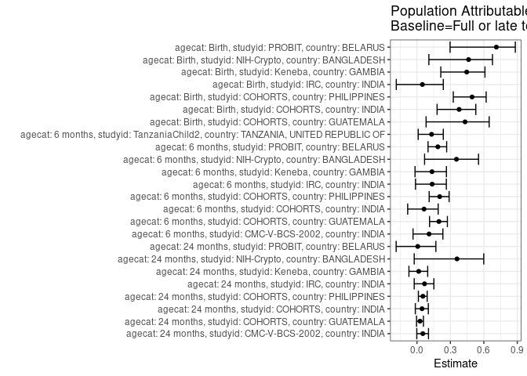

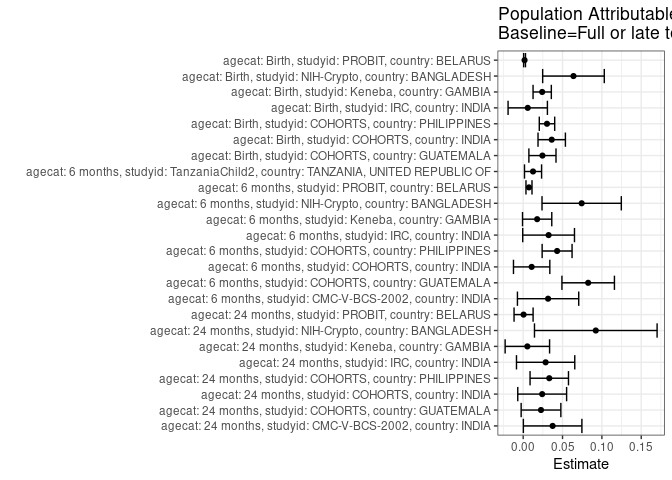

## Results Table

### Parameter: TSM

| agecat | studyid | country | intervention_level | baseline_level | estimate | ci_lower | ci_upper |
| --- | --- | --- | --- | --- | --- | --- | --- |
| Birth | COHORTS | GUATEMALA | Full or late term | NA | 0.0322581 | 0.0134899 | 0.0510262 |
| Birth | COHORTS | GUATEMALA | Preterm | NA | 0.1368421 | 0.0676760 | 0.2060082 |
| Birth | COHORTS | GUATEMALA | Early term | NA | 0.0607735 | 0.0259395 | 0.0956075 |
| Birth | COHORTS | INDIA | Full or late term | NA | 0.0596491 | 0.0401989 | 0.0790994 |
| Birth | COHORTS | INDIA | Preterm | NA | 0.1508772 | 0.1093062 | 0.1924482 |
| Birth | COHORTS | INDIA | Early term | NA | 0.1073059 | 0.0783097 | 0.1363022 |
| Birth | COHORTS | PHILIPPINES | Full or late term | NA | 0.0309278 | 0.0209807 | 0.0408749 |
| Birth | COHORTS | PHILIPPINES | Preterm | NA | 0.1355932 | 0.1092496 | 0.1619369 |
| Birth | COHORTS | PHILIPPINES | Early term | NA | 0.0503716 | 0.0380514 | 0.0626918 |
| Birth | IRC | INDIA | Full or late term | NA | 0.1134454 | 0.0730999 | 0.1537909 |
| Birth | IRC | INDIA | Preterm | NA | 0.2500000 | 0.1083597 | 0.3916403 |
| Birth | IRC | INDIA | Early term | NA | 0.0842105 | 0.0282919 | 0.1401292 |
| Birth | Keneba | GAMBIA | Full or late term | NA | 0.0299728 | 0.0176332 | 0.0423123 |
| Birth | Keneba | GAMBIA | Preterm | NA | 0.1489362 | 0.1034019 | 0.1944705 |
| Birth | Keneba | GAMBIA | Early term | NA | 0.0457875 | 0.0282491 | 0.0633260 |
| Birth | NIH-Crypto | BANGLADESH | Full or late term | NA | 0.0740741 | 0.0337180 | 0.1144301 |
| Birth | NIH-Crypto | BANGLADESH | Preterm | NA | 0.2490272 | 0.1961201 | 0.3019343 |
| Birth | NIH-Crypto | BANGLADESH | Early term | NA | 0.0798722 | 0.0498187 | 0.1099257 |
| Birth | PROBIT | BELARUS | Full or late term | NA | 0.0007042 | -0.0002235 | 0.0016320 |
| Birth | PROBIT | BELARUS | Preterm | NA | 0.0254237 | 0.0044461 | 0.0464013 |
| Birth | PROBIT | BELARUS | Early term | NA | 0.0026894 | 0.0008212 | 0.0045577 |
| 6 months | CMC-V-BCS-2002 | INDIA | Full or late term | NA | 0.2594340 | 0.2003456 | 0.3185224 |
| 6 months | CMC-V-BCS-2002 | INDIA | Preterm | NA | 0.4423077 | 0.3071214 | 0.5774940 |
| 6 months | CMC-V-BCS-2002 | INDIA | Early term | NA | 0.2771084 | 0.1806818 | 0.3735351 |
| 6 months | COHORTS | GUATEMALA | Full or late term | NA | 0.3367609 | 0.2897635 | 0.3837583 |
| 6 months | COHORTS | GUATEMALA | Preterm | NA | 0.5575221 | 0.4658810 | 0.6491633 |
| 6 months | COHORTS | GUATEMALA | Early term | NA | 0.4976303 | 0.4301190 | 0.5651417 |
| 6 months | COHORTS | INDIA | Full or late term | NA | 0.1584507 | 0.1284089 | 0.1884925 |
| 6 months | COHORTS | INDIA | Preterm | NA | 0.2274247 | 0.1798948 | 0.2749547 |
| 6 months | COHORTS | INDIA | Early term | NA | 0.1438202 | 0.1112046 | 0.1764359 |
| 6 months | COHORTS | PHILIPPINES | Full or late term | NA | 0.1682879 | 0.1454138 | 0.1911621 |
| 6 months | COHORTS | PHILIPPINES | Preterm | NA | 0.3001745 | 0.2626398 | 0.3377093 |
| 6 months | COHORTS | PHILIPPINES | Early term | NA | 0.2053407 | 0.1813114 | 0.2293700 |
| 6 months | IRC | INDIA | Full or late term | NA | 0.2048193 | 0.1546281 | 0.2550104 |
| 6 months | IRC | INDIA | Preterm | NA | 0.4523810 | 0.3016594 | 0.6031025 |
| 6 months | IRC | INDIA | Early term | NA | 0.2268041 | 0.1433606 | 0.3102477 |
| 6 months | Keneba | GAMBIA | Full or late term | NA | 0.1139818 | 0.0896915 | 0.1382720 |
| 6 months | Keneba | GAMBIA | Preterm | NA | 0.2270531 | 0.1699632 | 0.2841431 |
| 6 months | Keneba | GAMBIA | Early term | NA | 0.1159136 | 0.0880933 | 0.1437339 |
| 6 months | NIH-Crypto | BANGLADESH | Full or late term | NA | 0.1354839 | 0.0815680 | 0.1893997 |
| 6 months | NIH-Crypto | BANGLADESH | Preterm | NA | 0.2828685 | 0.2271106 | 0.3386265 |
| 6 months | NIH-Crypto | BANGLADESH | Early term | NA | 0.1877023 | 0.1441345 | 0.2312700 |
| 6 months | PROBIT | BELARUS | Full or late term | NA | 0.0319720 | 0.0233322 | 0.0406118 |
| 6 months | PROBIT | BELARUS | Preterm | NA | 0.0871143 | 0.0523430 | 0.1218857 |
| 6 months | PROBIT | BELARUS | Early term | NA | 0.0438767 | 0.0313451 | 0.0564083 |
| 6 months | TanzaniaChild2 | TANZANIA, UNITED REPUBLIC OF | Full or late term | NA | 0.0831191 | 0.0672762 | 0.0989620 |
| 6 months | TanzaniaChild2 | TANZANIA, UNITED REPUBLIC OF | Preterm | NA | 0.1340206 | 0.0948685 | 0.1731727 |
| 6 months | TanzaniaChild2 | TANZANIA, UNITED REPUBLIC OF | Early term | NA | 0.1033708 | 0.0750772 | 0.1316643 |
| 24 months | CMC-V-BCS-2002 | INDIA | Full or late term | NA | 0.6760563 | 0.6131191 | 0.7389936 |
| 24 months | CMC-V-BCS-2002 | INDIA | Preterm | NA | 0.7500000 | 0.6321390 | 0.8678610 |
| 24 months | CMC-V-BCS-2002 | INDIA | Early term | NA | 0.7857143 | 0.6978403 | 0.8735883 |
| 24 months | COHORTS | GUATEMALA | Full or late term | NA | 0.7973333 | 0.7566167 | 0.8380500 |
| 24 months | COHORTS | GUATEMALA | Preterm | NA | 0.8224299 | 0.7499664 | 0.8948934 |
| 24 months | COHORTS | GUATEMALA | Early term | NA | 0.8659218 | 0.8159680 | 0.9158756 |
| 24 months | COHORTS | INDIA | Full or late term | NA | 0.5079646 | 0.4667259 | 0.5492033 |
| 24 months | COHORTS | INDIA | Preterm | NA | 0.5475410 | 0.4916602 | 0.6034217 |
| 24 months | COHORTS | INDIA | Early term | NA | 0.5525114 | 0.5059272 | 0.5990956 |
| 24 months | COHORTS | PHILIPPINES | Full or late term | NA | 0.5906183 | 0.5591442 | 0.6220925 |
| 24 months | COHORTS | PHILIPPINES | Preterm | NA | 0.6627680 | 0.6218491 | 0.7036870 |
| 24 months | COHORTS | PHILIPPINES | Early term | NA | 0.6351490 | 0.6048954 | 0.6654026 |
| 24 months | IRC | INDIA | Full or late term | NA | 0.3920000 | 0.3314059 | 0.4525941 |
| 24 months | IRC | INDIA | Preterm | NA | 0.5476190 | 0.3968985 | 0.6983396 |
| 24 months | IRC | INDIA | Early term | NA | 0.4387755 | 0.3404011 | 0.5371499 |
| 24 months | Keneba | GAMBIA | Full or late term | NA | 0.3303411 | 0.2912645 | 0.3694177 |
| 24 months | Keneba | GAMBIA | Preterm | NA | 0.4311377 | 0.3559946 | 0.5062809 |
| 24 months | Keneba | GAMBIA | Early term | NA | 0.3055556 | 0.2620987 | 0.3490124 |
| 24 months | NIH-Crypto | BANGLADESH | Full or late term | NA | 0.1645570 | 0.0827154 | 0.2463985 |
| 24 months | NIH-Crypto | BANGLADESH | Preterm | NA | 0.3125000 | 0.2494477 | 0.3755523 |
| 24 months | NIH-Crypto | BANGLADESH | Early term | NA | 0.2378855 | 0.1824418 | 0.2933292 |
| 24 months | PROBIT | BELARUS | Full or late term | NA | 0.0676543 | 0.0401026 | 0.0952061 |
| 24 months | PROBIT | BELARUS | Preterm | NA | 0.0948905 | 0.0197637 | 0.1700173 |
| 24 months | PROBIT | BELARUS | Early term | NA | 0.0667379 | 0.0347048 | 0.0987709 |

### Parameter: E(Y)

| agecat | studyid | country | intervention_level | baseline_level | estimate | ci_lower | ci_upper |
| --- | --- | --- | --- | --- | --- | --- | --- |
| Birth | COHORTS | GUATEMALA | NA | NA | 0.0567261 | 0.0384591 | 0.0749931 |
| Birth | COHORTS | INDIA | NA | NA | 0.0959010 | 0.0798450 | 0.1119570 |
| Birth | COHORTS | PHILIPPINES | NA | NA | 0.0611772 | 0.0526341 | 0.0697204 |
| Birth | IRC | INDIA | NA | NA | 0.1192412 | 0.0861307 | 0.1523517 |
| Birth | Keneba | GAMBIA | NA | NA | 0.0541254 | 0.0427281 | 0.0655227 |
| Birth | NIH-Crypto | BANGLADESH | NA | NA | 0.1379781 | 0.1129774 | 0.1629789 |
| Birth | PROBIT | BELARUS | NA | NA | 0.0024473 | 0.0007336 | 0.0041610 |
| 6 months | CMC-V-BCS-2002 | INDIA | NA | NA | 0.2910663 | 0.2432023 | 0.3389303 |
| 6 months | COHORTS | GUATEMALA | NA | NA | 0.4193548 | 0.3831093 | 0.4556004 |
| 6 months | COHORTS | INDIA | NA | NA | 0.1692073 | 0.1489117 | 0.1895030 |
| 6 months | COHORTS | PHILIPPINES | NA | NA | 0.2113882 | 0.1959475 | 0.2268289 |
| 6 months | IRC | INDIA | NA | NA | 0.2371134 | 0.1947393 | 0.2794875 |
| 6 months | Keneba | GAMBIA | NA | NA | 0.1317322 | 0.1138432 | 0.1496211 |
| 6 months | NIH-Crypto | BANGLADESH | NA | NA | 0.2097902 | 0.1799252 | 0.2396552 |
| 6 months | PROBIT | BELARUS | NA | NA | 0.0393401 | 0.0293640 | 0.0493162 |
| 6 months | TanzaniaChild2 | TANZANIA, UNITED REPUBLIC OF | NA | NA | 0.0956385 | 0.0824215 | 0.1088554 |
| 24 months | CMC-V-BCS-2002 | INDIA | NA | NA | 0.7134670 | 0.6659628 | 0.7609713 |
| 24 months | COHORTS | GUATEMALA | NA | NA | 0.8199697 | 0.7906576 | 0.8492819 |
| 24 months | COHORTS | INDIA | NA | NA | 0.5321101 | 0.5050591 | 0.5591611 |
| 24 months | COHORTS | PHILIPPINES | NA | NA | 0.6237624 | 0.6044733 | 0.6430515 |
| 24 months | IRC | INDIA | NA | NA | 0.4205128 | 0.3714576 | 0.4695680 |
| 24 months | Keneba | GAMBIA | NA | NA | 0.3356401 | 0.3084071 | 0.3628732 |
| 24 months | NIH-Crypto | BANGLADESH | NA | NA | 0.2568093 | 0.2190047 | 0.2946140 |
| 24 months | PROBIT | BELARUS | NA | NA | 0.0681537 | 0.0420376 | 0.0942697 |

### Parameter: RR

| agecat | studyid | country | intervention_level | baseline_level | estimate | ci_lower | ci_upper |
| --- | --- | --- | --- | --- | --- | --- | --- |
| Birth | COHORTS | GUATEMALA | Full or late term | Full or late term | 1.0000000 | 1.0000000 | 1.000000 |
| Birth | COHORTS | GUATEMALA | Preterm | Full or late term | 4.2421053 | 1.9627721 | 9.168389 |
| Birth | COHORTS | GUATEMALA | Early term | Full or late term | 1.8839779 | 0.8324856 | 4.263584 |
| Birth | COHORTS | INDIA | Full or late term | Full or late term | 1.0000000 | 1.0000000 | 1.000000 |
| Birth | COHORTS | INDIA | Preterm | Full or late term | 2.5294118 | 1.6505151 | 3.876320 |
| Birth | COHORTS | INDIA | Early term | Full or late term | 1.7989525 | 1.1778748 | 2.747516 |
| Birth | COHORTS | PHILIPPINES | Full or late term | Full or late term | 1.0000000 | 1.0000000 | 1.000000 |
| Birth | COHORTS | PHILIPPINES | Preterm | Full or late term | 4.3841808 | 3.0109434 | 6.383727 |
| Birth | COHORTS | PHILIPPINES | Early term | Full or late term | 1.6286815 | 1.0873157 | 2.439589 |
| Birth | IRC | INDIA | Full or late term | Full or late term | 1.0000000 | 1.0000000 | 1.000000 |
| Birth | IRC | INDIA | Preterm | Full or late term | 2.2037037 | 1.1288592 | 4.301963 |
| Birth | IRC | INDIA | Early term | Full or late term | 0.7423002 | 0.3494922 | 1.576600 |
| Birth | Keneba | GAMBIA | Full or late term | Full or late term | 1.0000000 | 1.0000000 | 1.000000 |
| Birth | Keneba | GAMBIA | Preterm | Full or late term | 4.9690522 | 2.9755587 | 8.298099 |
| Birth | Keneba | GAMBIA | Early term | Full or late term | 1.5276390 | 0.8705747 | 2.680621 |
| Birth | NIH-Crypto | BANGLADESH | Full or late term | Full or late term | 1.0000000 | 1.0000000 | 1.000000 |
| Birth | NIH-Crypto | BANGLADESH | Preterm | Full or late term | 3.3618677 | 1.8733542 | 6.033111 |
| Birth | NIH-Crypto | BANGLADESH | Early term | Full or late term | 1.0782748 | 0.5561316 | 2.090650 |
| Birth | PROBIT | BELARUS | Full or late term | Full or late term | 1.0000000 | 1.0000000 | 1.000000 |
| Birth | PROBIT | BELARUS | Preterm | Full or late term | 36.1016949 | 10.3744573 | 125.628969 |
| Birth | PROBIT | BELARUS | Early term | Full or late term | 3.8190160 | 1.3496706 | 10.806254 |
| 6 months | CMC-V-BCS-2002 | INDIA | Full or late term | Full or late term | 1.0000000 | 1.0000000 | 1.000000 |
| 6 months | CMC-V-BCS-2002 | INDIA | Preterm | Full or late term | 1.7048951 | 1.1645510 | 2.495955 |
| 6 months | CMC-V-BCS-2002 | INDIA | Early term | Full or late term | 1.0681271 | 0.7047033 | 1.618973 |
| 6 months | COHORTS | GUATEMALA | Full or late term | Full or late term | 1.0000000 | 1.0000000 | 1.000000 |
| 6 months | COHORTS | GUATEMALA | Preterm | Full or late term | 1.6555428 | 1.3344287 | 2.053929 |
| 6 months | COHORTS | GUATEMALA | Early term | Full or late term | 1.4776962 | 1.2163479 | 1.795199 |
| 6 months | COHORTS | INDIA | Full or late term | Full or late term | 1.0000000 | 1.0000000 | 1.000000 |
| 6 months | COHORTS | INDIA | Preterm | Full or late term | 1.4353029 | 1.0824178 | 1.903234 |
| 6 months | COHORTS | INDIA | Early term | Full or late term | 0.9076654 | 0.6753833 | 1.219835 |
| 6 months | COHORTS | PHILIPPINES | Full or late term | Full or late term | 1.0000000 | 1.0000000 | 1.000000 |
| 6 months | COHORTS | PHILIPPINES | Preterm | Full or late term | 1.7836960 | 1.4828955 | 2.145513 |
| 6 months | COHORTS | PHILIPPINES | Early term | Full or late term | 1.2201748 | 1.0198306 | 1.459876 |
| 6 months | IRC | INDIA | Full or late term | Full or late term | 1.0000000 | 1.0000000 | 1.000000 |
| 6 months | IRC | INDIA | Preterm | Full or late term | 2.2086835 | 1.4605439 | 3.340045 |
| 6 months | IRC | INDIA | Early term | Full or late term | 1.1073378 | 0.7117056 | 1.722899 |
| 6 months | Keneba | GAMBIA | Full or late term | Full or late term | 1.0000000 | 1.0000000 | 1.000000 |
| 6 months | Keneba | GAMBIA | Preterm | Full or late term | 1.9920129 | 1.4326790 | 2.769717 |
| 6 months | Keneba | GAMBIA | Early term | Full or late term | 1.0169483 | 0.7377435 | 1.401820 |
| 6 months | NIH-Crypto | BANGLADESH | Full or late term | Full or late term | 1.0000000 | 1.0000000 | 1.000000 |
| 6 months | NIH-Crypto | BANGLADESH | Preterm | Full or late term | 2.0878391 | 1.3391510 | 3.255101 |
| 6 months | NIH-Crypto | BANGLADESH | Early term | Full or late term | 1.3854215 | 0.8739862 | 2.196136 |
| 6 months | PROBIT | BELARUS | Full or late term | Full or late term | 1.0000000 | 1.0000000 | 1.000000 |
| 6 months | PROBIT | BELARUS | Preterm | Full or late term | 2.7247051 | 1.7299462 | 4.291473 |
| 6 months | PROBIT | BELARUS | Early term | Full or late term | 1.3723467 | 1.1617732 | 1.621087 |
| 6 months | TanzaniaChild2 | TANZANIA, UNITED REPUBLIC OF | Full or late term | Full or late term | 1.0000000 | 1.0000000 | 1.000000 |
| 6 months | TanzaniaChild2 | TANZANIA, UNITED REPUBLIC OF | Preterm | Full or late term | 1.6123924 | 1.1375793 | 2.285387 |
| 6 months | TanzaniaChild2 | TANZANIA, UNITED REPUBLIC OF | Early term | Full or late term | 1.2436465 | 0.8909302 | 1.736002 |
| 24 months | CMC-V-BCS-2002 | INDIA | Full or late term | Full or late term | 1.0000000 | 1.0000000 | 1.000000 |
| 24 months | CMC-V-BCS-2002 | INDIA | Preterm | Full or late term | 1.1093750 | 0.9241728 | 1.331691 |
| 24 months | CMC-V-BCS-2002 | INDIA | Early term | Full or late term | 1.1622024 | 1.0048130 | 1.344245 |
| 24 months | COHORTS | GUATEMALA | Full or late term | Full or late term | 1.0000000 | 1.0000000 | 1.000000 |
| 24 months | COHORTS | GUATEMALA | Preterm | Full or late term | 1.0314756 | 0.9316040 | 1.142054 |
| 24 months | COHORTS | GUATEMALA | Early term | Full or late term | 1.0860223 | 1.0054932 | 1.173001 |
| 24 months | COHORTS | INDIA | Full or late term | Full or late term | 1.0000000 | 1.0000000 | 1.000000 |
| 24 months | COHORTS | INDIA | Preterm | Full or late term | 1.0779117 | 0.9461218 | 1.228059 |
| 24 months | COHORTS | INDIA | Early term | Full or late term | 1.0876967 | 0.9675548 | 1.222757 |
| 24 months | COHORTS | PHILIPPINES | Full or late term | Full or late term | 1.0000000 | 1.0000000 | 1.000000 |
| 24 months | COHORTS | PHILIPPINES | Preterm | Full or late term | 1.1221596 | 1.0342719 | 1.217516 |
| 24 months | COHORTS | PHILIPPINES | Early term | Full or late term | 1.0753967 | 1.0012154 | 1.155074 |
| 24 months | IRC | INDIA | Full or late term | Full or late term | 1.0000000 | 1.0000000 | 1.000000 |
| 24 months | IRC | INDIA | Preterm | Full or late term | 1.3969874 | 1.0188273 | 1.915510 |
| 24 months | IRC | INDIA | Early term | Full or late term | 1.1193253 | 0.8524862 | 1.469688 |
| 24 months | Keneba | GAMBIA | Full or late term | Full or late term | 1.0000000 | 1.0000000 | 1.000000 |
| 24 months | Keneba | GAMBIA | Preterm | Full or late term | 1.3051289 | 1.0572380 | 1.611143 |
| 24 months | Keneba | GAMBIA | Early term | Full or late term | 0.9249698 | 0.7687566 | 1.112926 |
| 24 months | NIH-Crypto | BANGLADESH | Full or late term | Full or late term | 1.0000000 | 1.0000000 | 1.000000 |
| 24 months | NIH-Crypto | BANGLADESH | Preterm | Full or late term | 1.8990385 | 1.1103037 | 3.248073 |
| 24 months | NIH-Crypto | BANGLADESH | Early term | Full or late term | 1.4456117 | 0.8346730 | 2.503727 |
| 24 months | PROBIT | BELARUS | Full or late term | Full or late term | 1.0000000 | 1.0000000 | 1.000000 |
| 24 months | PROBIT | BELARUS | Preterm | Full or late term | 1.4025787 | 0.5747799 | 3.422574 |
| 24 months | PROBIT | BELARUS | Early term | Full or late term | 0.9864537 | 0.6763897 | 1.438654 |

### Parameter: PAR

| agecat | studyid | country | intervention_level | baseline_level | estimate | ci_lower | ci_upper |
| --- | --- | --- | --- | --- | --- | --- | --- |
| Birth | COHORTS | GUATEMALA | Full or late term | NA | 0.0244680 | 0.0072466 | 0.0416894 |
| Birth | COHORTS | INDIA | Full or late term | NA | 0.0362519 | 0.0188576 | 0.0536461 |
| Birth | COHORTS | PHILIPPINES | Full or late term | NA | 0.0302494 | 0.0204638 | 0.0400350 |
| Birth | IRC | INDIA | Full or late term | NA | 0.0057958 | -0.0191902 | 0.0307818 |
| Birth | Keneba | GAMBIA | Full or late term | NA | 0.0241527 | 0.0125500 | 0.0357554 |
| Birth | NIH-Crypto | BANGLADESH | Full or late term | NA | 0.0639041 | 0.0247532 | 0.1030549 |
| Birth | PROBIT | BELARUS | Full or late term | NA | 0.0017431 | 0.0005871 | 0.0028990 |
| 6 months | CMC-V-BCS-2002 | INDIA | Full or late term | NA | 0.0316323 | -0.0073061 | 0.0705708 |
| 6 months | COHORTS | GUATEMALA | Full or late term | NA | 0.0825939 | 0.0492416 | 0.1159462 |
| 6 months | COHORTS | INDIA | Full or late term | NA | 0.0107566 | -0.0123298 | 0.0338430 |
| 6 months | COHORTS | PHILIPPINES | Full or late term | NA | 0.0431002 | 0.0240927 | 0.0621078 |
| 6 months | IRC | INDIA | Full or late term | NA | 0.0322941 | -0.0005901 | 0.0651784 |
| 6 months | Keneba | GAMBIA | Full or late term | NA | 0.0177504 | -0.0008217 | 0.0363225 |
| 6 months | NIH-Crypto | BANGLADESH | Full or late term | NA | 0.0743063 | 0.0239228 | 0.1246898 |
| 6 months | PROBIT | BELARUS | Full or late term | NA | 0.0073681 | 0.0035411 | 0.0111950 |
| 6 months | TanzaniaChild2 | TANZANIA, UNITED REPUBLIC OF | Full or late term | NA | 0.0125194 | 0.0016639 | 0.0233748 |
| 24 months | CMC-V-BCS-2002 | INDIA | Full or late term | NA | 0.0374107 | 0.0002258 | 0.0745956 |
| 24 months | COHORTS | GUATEMALA | Full or late term | NA | 0.0226364 | -0.0025823 | 0.0478551 |
| 24 months | COHORTS | INDIA | Full or late term | NA | 0.0241455 | -0.0068898 | 0.0551807 |
| 24 months | COHORTS | PHILIPPINES | Full or late term | NA | 0.0331440 | 0.0087305 | 0.0575576 |
| 24 months | IRC | INDIA | Full or late term | NA | 0.0285128 | -0.0085117 | 0.0655374 |
| 24 months | Keneba | GAMBIA | Full or late term | NA | 0.0052990 | -0.0229342 | 0.0335323 |
| 24 months | NIH-Crypto | BANGLADESH | Full or late term | NA | 0.0922524 | 0.0143531 | 0.1701517 |
| 24 months | PROBIT | BELARUS | Full or late term | NA | 0.0004993 | -0.0116016 | 0.0126002 |

### Parameter: PAF

| agecat | studyid | country | intervention_level | baseline_level | estimate | ci_lower | ci_upper |
| --- | --- | --- | --- | --- | --- | --- | --- |
| Birth | COHORTS | GUATEMALA | Full or late term | NA | 0.4313364 | 0.0819272 | 0.6477640 |
| Birth | COHORTS | INDIA | Full or late term | NA | 0.3780136 | 0.1805054 | 0.5279199 |
| Birth | COHORTS | PHILIPPINES | Full or late term | NA | 0.4944553 | 0.3260309 | 0.6207906 |
| Birth | IRC | INDIA | Full or late term | NA | 0.0486058 | -0.1854004 | 0.2364176 |
| Birth | Keneba | GAMBIA | Full or late term | NA | 0.4462351 | 0.2137384 | 0.6099828 |
| Birth | NIH-Crypto | BANGLADESH | Full or late term | NA | 0.4631463 | 0.1068457 | 0.6773101 |
| Birth | PROBIT | BELARUS | Full or late term | NA | 0.7122411 | 0.2970627 | 0.8822012 |
| 6 months | CMC-V-BCS-2002 | INDIA | Full or late term | NA | 0.1086774 | -0.0352902 | 0.2326248 |
| 6 months | COHORTS | GUATEMALA | Full or late term | NA | 0.1969547 | 0.1130293 | 0.2729391 |
| 6 months | COHORTS | INDIA | Full or late term | NA | 0.0635706 | -0.0831558 | 0.1904212 |
| 6 months | COHORTS | PHILIPPINES | Full or late term | NA | 0.2038914 | 0.1094932 | 0.2882829 |
| 6 months | IRC | INDIA | Full or late term | NA | 0.1361970 | -0.0130777 | 0.2634764 |
| 6 months | Keneba | GAMBIA | Full or late term | NA | 0.1347462 | -0.0173400 | 0.2640964 |
| 6 months | NIH-Crypto | BANGLADESH | Full or late term | NA | 0.3541935 | 0.0683540 | 0.5523343 |
| 6 months | PROBIT | BELARUS | Full or late term | NA | 0.1872918 | 0.0995928 | 0.2664489 |
| 6 months | TanzaniaChild2 | TANZANIA, UNITED REPUBLIC OF | Full or late term | NA | 0.1309029 | 0.0109997 | 0.2362695 |
| 24 months | CMC-V-BCS-2002 | INDIA | Full or late term | NA | 0.0524351 | -0.0016012 | 0.1035561 |
| 24 months | COHORTS | GUATEMALA | Full or late term | NA | 0.0276064 | -0.0037690 | 0.0580010 |
| 24 months | COHORTS | INDIA | Full or late term | NA | 0.0453769 | -0.0148234 | 0.1020060 |
| 24 months | COHORTS | PHILIPPINES | Full or late term | NA | 0.0531357 | 0.0130995 | 0.0915477 |
| 24 months | IRC | INDIA | Full or late term | NA | 0.0678049 | -0.0246711 | 0.1519350 |
| 24 months | Keneba | GAMBIA | Full or late term | NA | 0.0157878 | -0.0720290 | 0.0964110 |
| 24 months | NIH-Crypto | BANGLADESH | Full or late term | NA | 0.3592252 | -0.0245831 | 0.5992591 |
| 24 months | PROBIT | BELARUS | Full or late term | NA | 0.0073266 | -0.1867541 | 0.1696675 |